# Estimating reference points

Kyle L. Wilson

2025-10-11

```r
library(mvtnorm)
library(marima)
library(diagram)
library(vioplot)
library(ggplot2)
```

# Part 1: Population model

## Population dynamics

Our population is defined by as a species with a one year generation time with time-dynamics that follows birth (i.e., recruitment *R*) and death processes (i.e., fishing mortality *d*) such that:

$$\begin{align}
N_{t}=(1-d_{t})R_{t}
\end{align}$$

where $N_{t}$ is the number of adults at time *t*, $R_{t}$ is the number of recruits at time *t*, and $d_{t}$ is the fraction of recruits lost due to some source of mortality (i.e., the cumulative product of marine survival, harvest, or other disturbance). It then follows that $1-d_{t}$ is discrete survival. In many instances for fisheries dynamics, we might model this using continuous rates of mortality $M_t$ and $F_t$ such that: $d_t=1-e^{-M_t+F_t}$ - but lets ignore this for now.

## Beverton-Holt recruitment

Let’s assume that our recruitment dynamics at time *t* depend on adult densities at *t-1* following a reparameterized Beverton-Holt function based on compensation ratio (see Box 3.1 in Walters & Martell 2004) and ignoring age-structure so that we model adult-to-adult dynamics, i.e., setting $\phi_{E_{0}}=1$, $\phi_{B_{0}}=1$ and $R_0=N_0$ (see Table 3 in Forrest et al. 2010):

$$\begin{align}
R_{t}=\cfrac{{\alpha}N_{t-1}}{1+\cfrac{\alpha}{\beta}N_{t-1}}\epsilon_{t}
\end{align}$$

where $\alpha$ is the recruitment compensation ratio, $\beta$ is carrying capacity, and $\epsilon_{i,t}$ is lognormally distributed deviates to introduce stochastic recruitment dynamics (Methot & Taylor (2011)).

So effectively the number of adults at time *t* is a function of the abundance of adults at a previous time-step *t-1* that survived some potential harvest regime. Let’s assume $d_t=0$ to begin:
$$\begin{align}
N_{t}=(1-d_{t})*\cfrac{{\alpha}N_{t-1}}{1+\cfrac{\alpha}{\beta}N_{t-1}}\epsilon_{t}
\end{align}$$

```r
alpha <- c(2,4)
beta <- c(100,200)
```

For example, take a two different populations that each vary in productivity $\alpha_1=2; \alpha_2=4$ and carrying capacity $\beta_1=100; \beta_2=200$.

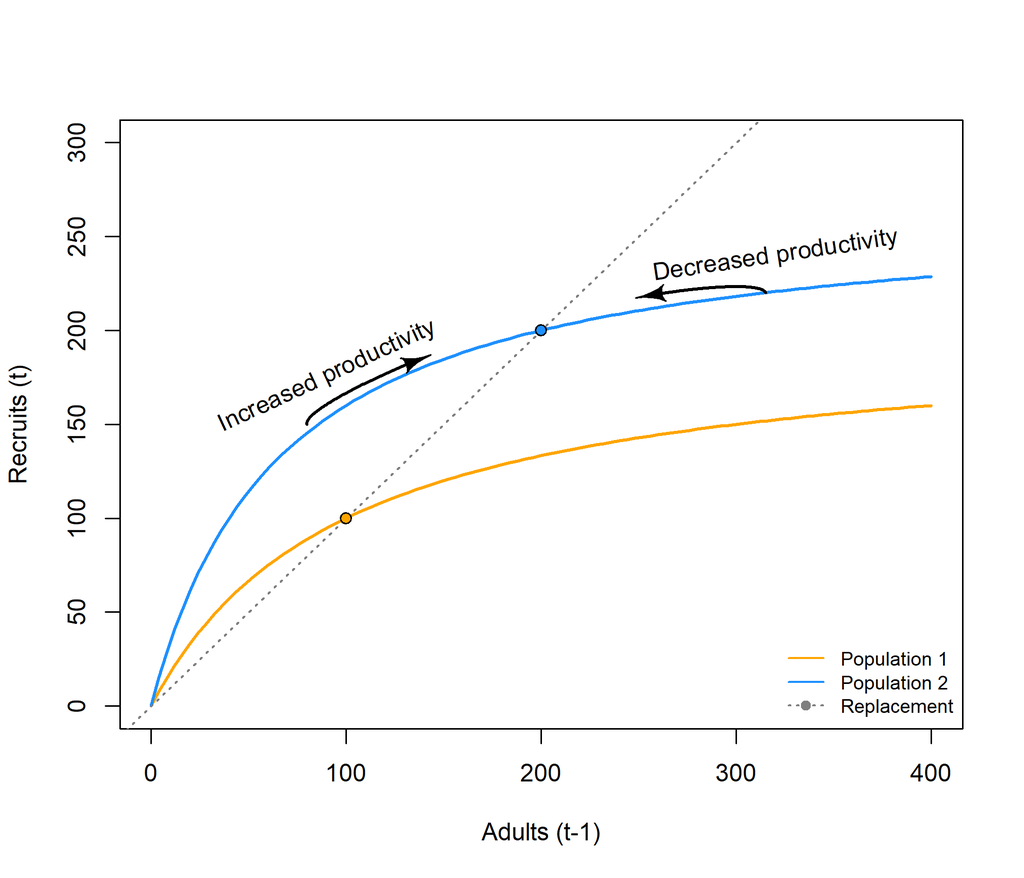

Density dependence in recruitment dynamics. Dashed line indicates the line of replacement, with equilbrium indicated by points. When populations fall below equilibrium points, per-capita productivity improves driving populations back towards equilibrium. When populations exceed their capacity, per-capita productivity decreases driving populations back towards equilibrium. At each point of the x-axis, the difference between the solid and dashed lines indicates the amount of recruitment above replacement, i.e., the surplus recruitment produced via compensatory density dependence.

```r
curve((alpha[1]*x)/(1+((alpha[1]-1)/beta[1])*x),from=0,to=2*beta[2],lwd=2,col="orange",xlab="Adults (t-1)",ylab="Recruits (t)",ylim=1.5*c(0,beta[2]),xlim=2*c(0,beta[2]))
curve((alpha[2]*x)/(1+((alpha[2]-1)/beta[2])*x),from=0,to=2*beta[2],lwd=2,col="dodgerblue",add=TRUE)
abline(b=1,a=0,lty=3,lwd=1.5,col="grey50")

curvedarrow(from=c(0.4*beta[2],0.75*beta[2]),to=c(beta[2],beta[2]),lwd=2,lty=1,lcol="black",arr.col="black",curve=-0.075,endhead=TRUE,arr.pos=0.5)
curvedarrow(from=c(1.575*beta[2],1.1*beta[2]),to=c(beta[2],beta[2]),lwd=2,lty=1,lcol="black",arr.col="black",curve=0.075,endhead=TRUE,arr.pos=0.5)

text(x=0.45*beta[2],y=0.88*beta[2],"Increased productivity",cex=1,srt=25)
text(x=1.60*beta[2],y=1.20*beta[2],"Decreased productivity",cex=1,srt=8.5)

points(c(beta),c(beta),pch=21,bg=c("orange","dodgerblue"))
legend("bottomright",c("Population 1","Population 2","Replacement"),bty="n",lwd=1.5,lty=c(1,1,3),pch=c(NA,NA,21),col=c("orange","dodgerblue","grey50"),pt.bg="grey50",cex=0.8)
```

## Sustainable Fisheries Framework: reference points

The SFF and updates to the Fisheries Act ask that reference points be established for Canada’s major fisheries. Reference points delinates zones of risk: from ‘healthy’ to ‘cautious’ and from ‘cautious’ to ‘concern’ (red). These two reference points are referred to as the **Upper Stock Reference Point** and the **Limit Reference Point**

Based on these $\alpha$ and $\beta$ demographic parameters, we can use numerical methods to estimate various spawner, recruitment, or fisheries reference points. The most common ones are based on Maximum Sustainable Yield. Others might be based on fractions of *carrying capacity*: but this depends on whether we are interested in the *recruits at carrying capacity* $R_0$ or *spawners at carrying capacity* ($N_0$). In this version of the recruitment model, $\beta=R_{0}=N_{0}$ because, when adult mortality is $d_t=0$, then we are only modelling how current spawning adults create future spawning adults. Sometimes, we are modelling how current spawning adult abundances (or spawner biomass) create future juveniles (either in abundance or biomass) and $R_{0} \neq N_{0}$.

### Beverton-Holt and Ricker: two sides of the same coin

Let’s make a function that let’s us tap into the same input parameters, but ask what the expected recruits would be under assumptions of a *Beverton-Holt* compared to a *Ricker* model. We will start with *Beverton-Holt*, but its easy to change this later. The point is that the numerical methods we learn below work the same between any population dynamics models that we choose, just requires different equations on the *r.h.s* of things. We will work with a population that has $\alpha=5$ and *spawners at carrying capacity* $\beta=200$

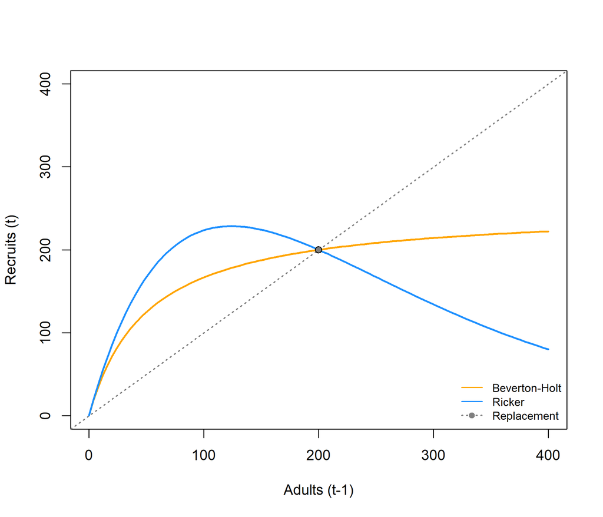

Comparison between Beverton-Holt and Ricker recruitment model.

```r
alpha <- 5
beta <- 200
population_model <- function(alpha,beta,Nadults,model="Beverton-Holt")
{
  if(model=="Beverton-Holt")
  {
    # population model is R ~ (CR * S)/(1+(CR-1)/K * S): reparameterized Beverton-Holt
    recruits <- (alpha*Nadults)/(1+((alpha-1)/beta)*Nadults)
  }
  if(model=="Ricker")
  {
    # population model is R ~ CR * S * e(-log(CR)/K * S): reparameterized Ricker
    recruits <- alpha*Nadults*exp(-log(alpha)/beta*Nadults)
  }
  return(list("recruits"=recruits))
}

curve(population_model(alpha=alpha,beta=beta,Nadults=x,model="Beverton-Holt")$recruits,from=0,to=2*beta,lwd=2,col="orange",xlab="Adults (t-1)",ylab="Recruits (t)",ylim=c(0,2*beta))
curve(population_model(alpha=alpha,beta=beta,Nadults=x,model="Ricker")$recruits,from=0,to=2*beta,lwd=2,col="dodgerblue",add=TRUE)
abline(b=1,a=0,lty=3,lwd=1.5,col="grey50")
points(c(beta,beta),c(beta,beta),pch=21,bg="grey50",col="black")
legend("bottomright",c("Beverton-Holt","Ricker","Replacement"),bty="n",lwd=1.5,lty=c(1,1,3),pch=c(NA,NA,21),col=c("orange","dodgerblue","grey50"),pt.bg="grey50",cex=0.8)
```

### MSY

Maximum Sustainable Yield *MSY* is the most fish (biomass or abundance) that can be removed from the population over the long-term given the productivity of the population. It is a very helpful thing to know about the population, and it has a clear numerical solution as it occurs at the *maximum* of a yield curve. The *SFF* and Wild Salmon Policy (*WSP*) delineate healthy from not healthy fish populations using the *USR* - de facto DFO policies sets the *USR* to be $0.8S_{MSY}$ for reasons that aren’t well established. The United States NOAA National Marine Fisheries Service, for instance, uses $S_{MSY}$. Where the missing 20% went, who knows but see Frid et al. (2023) for our thoughts.

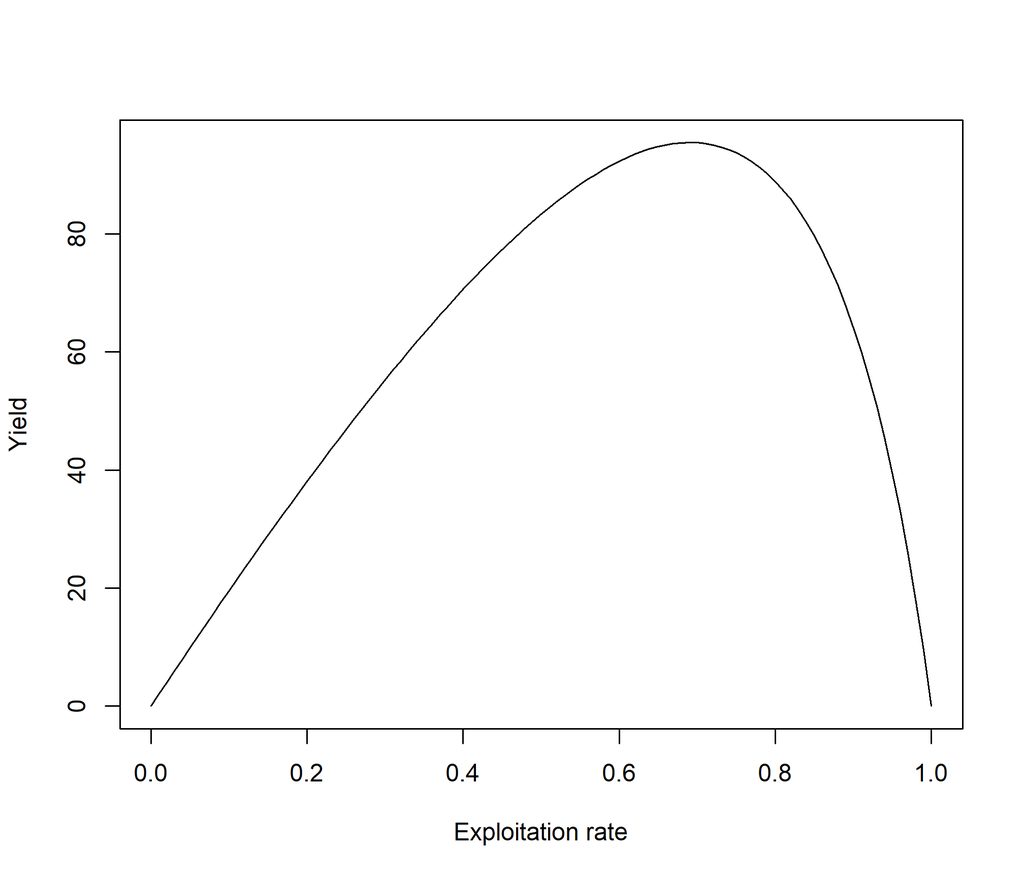

Yield curve indicating the amount of total catch (numbers or biomass) that can be expected given a certain amount of exploitation. The peak of this curve indicates the maximum sustainable yield that can be extracted from this population in perpetuity, given no changes in their demographics, etc.

```r
umsy_find <- function(u_x,alpha, beta,model="Beverton-Holt")
{
  if(model=="Beverton-Holt")
  {
    # population model is R ~ (CR * S)/(1+(CR-1)/K * S): reparameterized Beverton-Holt
    adults <- (1-u_x)*beta
    recruits <- population_model(alpha=alpha,beta=beta,Nadults=adults,model="Beverton-Holt")$recruits
    yield <- u_x*recruits
  }
  if(model=="Ricker")
  {
    # population model is R ~ CR * S * e(-log(CR)/K * S): reparameterized Ricker
    adults <- (1-u_x)*beta
    recruits <- population_model(alpha=alpha,beta=beta,Nadults=adults,model="Ricker")$recruits
    yield <- u_x*recruits
  }
  return(yield)
}

curve(umsy_find(u_x=x,alpha=alpha,beta=beta),from=0,to=1,xlab="Exploitation rate",ylab="Yield")
```

```r
umsy <- optimize(umsy_find,c(0,1),tol=0.0001,alpha=alpha,beta=beta,maximum = TRUE)$maximum
S_msy <- (1-umsy)*beta
MSY <- umsy*population_model(alpha=alpha,beta=beta,Nadults=S_msy,model="Beverton-Holt")$recruits

data.frame("U"=umsy,"Smsy"=S_msy,"MSY"=MSY)
```

```
## # A tibble: 1 × 3
##       U  Smsy   MSY
##   <dbl> <dbl> <dbl>
## 1 0.691  61.8  95.5
```

### Limit reference point: S(gen)

Then, we will estimate one version of a *Limit Reference Point* called S(gen). S(gen) is the spawner abundance that, in the absence of fishing, can reach S(MSY) within 1 generation based on its current productivity. It is a conservation-based benchmark and lets us know how depleted the population can get before we need to curtail harvest while still maintaining the ability to get back to MSY fairly quick.

```r
Sgen_find <- function(Smsy,Sgen,alpha,beta)
{
  (Smsy-population_model(alpha=alpha,beta=beta,Nadults=Sgen,model="Beverton-Holt")$recruits)^2
}

Sgen <- optimize(Sgen_find,c(0,S_msy),tol=0.0001,Smsy=S_msy,alpha=alpha,beta=beta)$minimum
Sgen
```

```
## [1] 16.421
```

### Reference points: visualized

Now, we have our **SFF** reference points for a 1-year generation time population. Let’s plot this out:

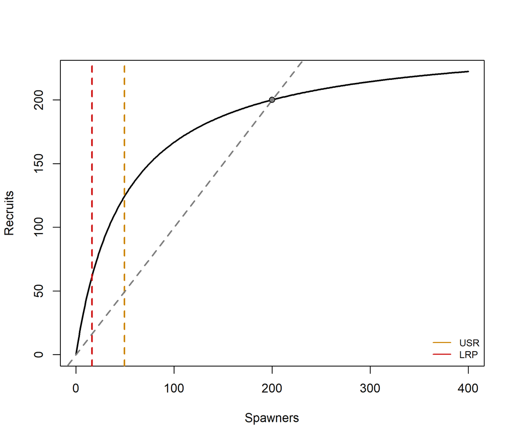

Relationship between current adults and future recruits and Wild Salmon Policy and Sustainable Fisheries Framework reference points. USR: Upper Stock Reference Point (often 0.8S(MSY)). LRP: Limit Reference Point (here, we used S(GEN).

```r
plot(0:(2*beta),population_model(alpha=alpha,beta=beta,0:(2*beta))$recruits,xlab="Spawners",ylab="Recruits",type="l",lwd=2)
abline(v=0.8*S_msy,lty=2,lwd=2,col="orange3")
abline(v=Sgen,lty=2,lwd=2,col="red3")
abline(a=0,b=1,lty=2,lwd=2,col="grey50")
points(beta,beta,pch=21,bg="grey50",col="black")
legend("bottomright",c("USR","LRP"),bty="n",lwd=1.5,lty=c(1,1),pch=c(NA,NA),col=c("orange3","red3"),cex=0.8)
```

In this parameterization of the Beverton-Holt model (and there are several parameterizations that exist),

$S_{MSY}=(\sqrt\alpha-1)/(\alpha-1)/\beta)$, which for our case is: 61.8034

But this doesn’t work for all models. And, in our case, numerical solution for $S_{MSY}$ (61.80552) gives a pretty close approximation to the analytical solution (61.8034) and works in many, many situations.

# Part II: case study with simulation

## Recruitment stochasticity

We can model stochastic recruitment and, in this case, we will use a lognormal distribution with average variation in recruitment of $\sigma_R$. In cases with stochastic recruitment, the deterministic recruitment becomes:

$$\begin{align}
R_{t}=\cfrac{{\alpha}N_{t-1}}{1+\cfrac{{\alpha}}{\beta}N_{t-1}}e^{\epsilon_{t}-\cfrac{\sigma_{R}^2}{2}}
\end{align}$$

where lognormal deviates at time *t* is drawn from a normal distribution (*N*) with bias correction $\cfrac{\sigma_{R}^2}{2}$. If $\sigma_R$ is low, then population dynamics approach the deterministic case. In some scenarios, we may want to evaluate the role of temporally correlated recruitment deviates to model potential drivers synchronous or correlated dynamics. Expected recruitment deviates can follow a first-order autoregressive model such that:

$$\begin{align}
\epsilon_{t}=\rho\epsilon_{t-1}+N(\mu=0,\sigma=\sqrt{\sigma_R^2(1-\rho^2)})
\end{align}$$

where $\rho$ is temporal correlation (bounded $0-1$). If $\rho$ is 0, then annual recruitment deviates were independent. We modelled the initial conditions for autoregressive recruitment deviates $\epsilon_{1}$ by drawing from a stationary normal distribution with mean $\mu=0$ and variance $\sigma_R^2$ such that:
$$\begin{align}
\epsilon_{1} \sim N(\mu=0,\sigma=\sigma_R)
\end{align}$$
We illustrate the effects of two kinds of recruitment deviates below using the same random number generator seed:

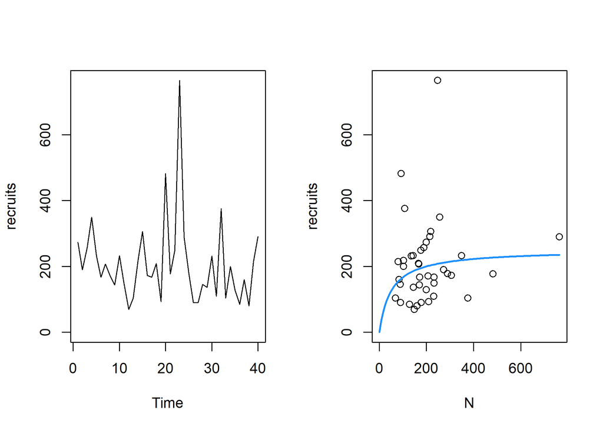

Population dynamics over time assuming independent recruitment deviates.

```r
Nyears <- 40
seed <- 2025
rho <- 0.9
sigma_r <- 0.5
set.seed(seed) # sets the random numbers to the same values for everyone
epsilon <- rnorm(Nyears,mean=0,sd=sigma_r)
N <- recruits <- rep(NA,Nyears)
N[1] <- beta
recruits[1] <- alpha*N[1]/(1+((alpha-1)/beta)*N[1])*exp(epsilon[1])
for(t in 2:Nyears)
{
  N[t] <- recruits[t-1]
  recruits[t] <- alpha*N[t]/(1+((alpha-1)/beta)*N[t])*exp(epsilon[t]-(sigma_r^2)/2)
}
layout(matrix(1:2,ncol=2))
plot(1:Nyears,recruits,xlab="Time",ylim=range(c(0,recruits)),type="l")
plot(N,recruits,xlim=range(c(0,N)),ylim=range(c(0,recruits)))
curve((alpha*x)/(1+((alpha-1)/beta)*x),from=0,lwd=2,col="dodgerblue",add=TRUE)
```

```r
head(data.frame("Adults"=N,"Recruits"=recruits))
```

```
## # A tibble: 6 × 2
##   Adults Recruits
##    <dbl>    <dbl>
## 1   200      273.
## 2   273.     190.
## 3   190.     257.
## 4   257.     349.
## 5   349.     232.
## 6   232.     167.
```

```r
print(c("sd in simulated recruitment (independent)",round(sd(epsilon),2)))
```

```
## [1] "sd in simulated recruitment (independent)"
## [2] "0.51"
```

```r
df1 <- data.frame("Year"=1:Nyears,"Adults"=N,"Recruits"=recruits,"variance"="independent")
```

Next, we will repeat this but for autocorrelated recruitment. Note the reduced “white noise” or bumpiness in the below plot compared to the above. Instead, “good years” are correlated to subsequent “good years” and “bad years” seem to lead to subsequent “bad years”. This pattern is somewhat common in population dynamics due to temporally correlated environmental drivers, like back-to-back El Nino and La Nina years or North Pacific Gyre oscillations.

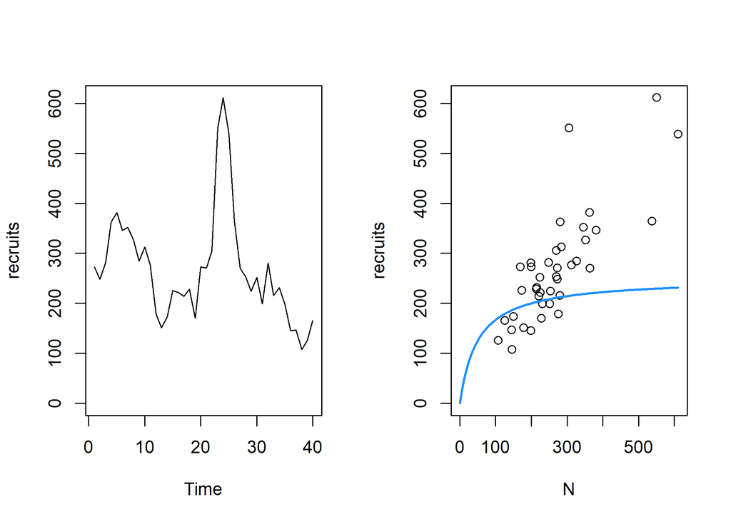

Population dynamics over time assuming autocorrelated recruitment deviates.

```r
set.seed(seed) # resets the random numbers
epsilon <- rnorm(1,mean=0,sd=sigma_r)
N <- recruits <- rep(NA,Nyears)
N[1] <- beta
recruits[1] <- alpha*N[1]/(1+((alpha-1)/beta)*N[1])*exp(epsilon[1])
for(t in 2:Nyears)
{
  epsilon[t] <- rho*epsilon[t-1] + rnorm(1,mean=0,sd=sqrt((sigma_r^2)*(1-rho^2)))
  N[t] <- recruits[t-1]
  recruits[t] <- alpha*N[t]/(1+((alpha-1)/beta)*N[t])*exp(epsilon[t]-(sigma_r^2)/2)
}

layout(matrix(1:2,ncol=2))
plot(1:Nyears,recruits,xlab="Time",ylim=range(c(0,recruits)),type="l")
plot(N,recruits,xlim=range(c(0,N)),ylim=range(c(0,recruits)))
curve((alpha*x)/(1+((alpha-1)/beta)*x),from=0,lwd=2,col="dodgerblue",add=TRUE)
```

```r
head(data.frame("Adults"=N,"Recruits"=recruits))
```

```
## # A tibble: 6 × 2
##   Adults Recruits
##    <dbl>    <dbl>
## 1   200      273.
## 2   273.     248.
## 3   248.     281.
## 4   281.     363.
## 5   363.     381.
## 6   381.     346.
```

```r
print(c("sd in simulated recruitment (correlated)",round(sd(epsilon),2)))
```

```
## [1] "sd in simulated recruitment (correlated)"
## [2] "0.33"
```

```r
df2 <- data.frame("Year"=1:Nyears,"Adults"=N,"Recruits"=recruits,"variance"="correlated")

df <- rbind(df1,df2)
```

## Estimating recruitment model

Let’s estimate the Beverton-Holt model by fitting it to our simulated stock-recruit dataset. We can assume the *independent* correlation structure for now, but really we would just revise the equation for $\mu$ below. Here, we are using the R function called `optim` in order to find the *most likely* fit of a Beverton-Holt model to this dataset, presuming a *lognormal* error structure. `optim` is just another numerical tool to find the *minimum* or *maximum* solution to a problem.

First, we will creating a function called `mle_fit` and get `R` to solve this for us on our behalf. We then read in potential starting parameters for $\alpha$ and $\beta$, and this will let `optim` to get going. Understanding how functions work in R is the main trick here, and may take some time.

For our purposes, we will apply the bias-correction term $\sigma^2/2$ by subtracting that from the log of the mean expected recruitment $log_e(\mu)$. This is a common approach to adjust estimated recruitment curves in the face of noisy stock-recruitment data (assuming lognormally distributed error) used in fisheries assessments (Methot & Taylor (2011)).

```r
df_sub <- df[df$variance=="independent",]
mle_fit <- function(par,dataset)
{
  # theta <- start
  alpha <- exp(par[1])
  beta <- par[2]
  sigma <- exp(par[3])
  # data <- df_sub
  mu <- (alpha*dataset$Adults)/(1+((alpha-1)/beta)*dataset$Adults)
  log_lik <- dlnorm(x=dataset$Recruits,meanlog=log(mu)-((sigma^2)/2),sdlog=sigma,log=TRUE)
  nll <- -sum(log_lik)
  return(nll)
}
start <- c(log(2),mean(df_sub$Recruits),0)
fit <- optim(par=start,fn=mle_fit,dataset=df_sub,method="BFGS",hessian=TRUE)
par <- fit$par
alpha_est <- exp(par[1])
beta_est <- par[2]
sigma_est <- exp(par[3])

parameters <- data.frame("alpha"=c(alpha,alpha_est),"beta"=c(beta,beta_est),"sigma"=c(sigma_r,sigma_est),"type"=c("true","estimate"))
parameters
```

```
## # A tibble: 2 × 4
##   alpha  beta sigma type
##   <dbl> <dbl> <dbl> <chr>
## 1  5     200  0.5   true
## 2  9.87  211. 0.503 estimate
```

### Estimating MSY from model fit

Once we have the *MLE* solutions for $\alpha$ and $\beta$ for our presumed Beverton-Holt model, we have all the ingredients we need to then estimate our fishery reference points.

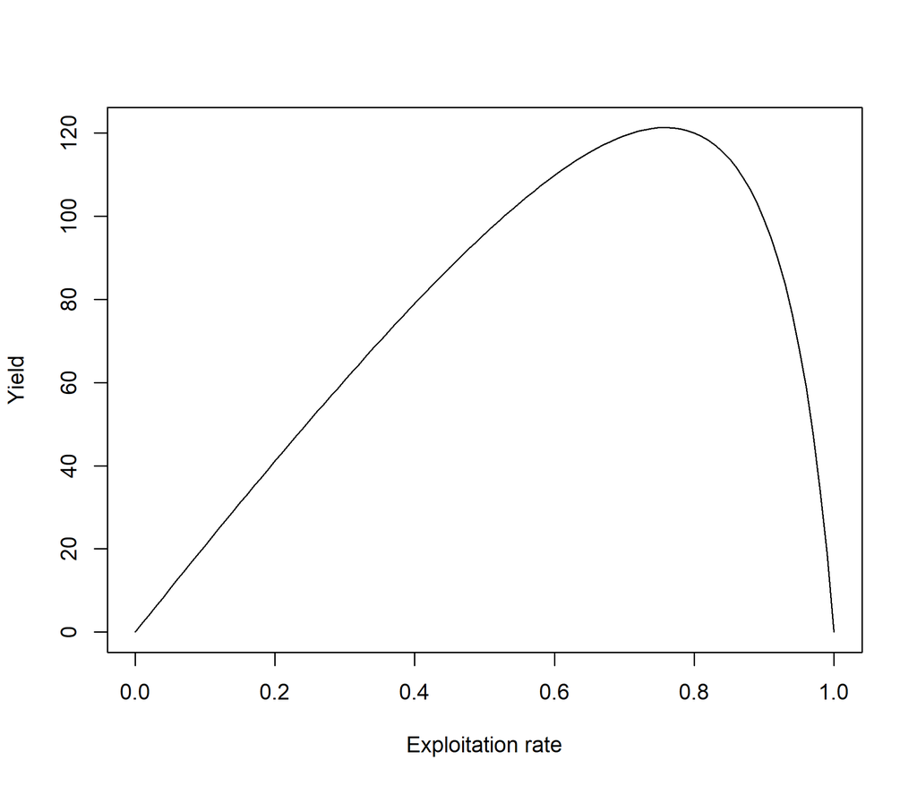

```r
curve(umsy_find(u_x=x,alpha=alpha_est,beta=beta_est),from=0,to=1,xlab="Exploitation rate",ylab="Yield")
```

```r
umsy_est <- optimize(umsy_find,c(0,1),tol=0.0001,alpha=alpha_est,beta=beta_est,maximum = TRUE)$maximum
S_msy_est <- (1-umsy_est)*beta_est
MSY_est <- umsy_est*population_model(alpha=alpha_est,beta=beta_est,Nadults=S_msy_est,model="Beverton-Holt")$recruits

Sgen_est <- optimize(Sgen_find,c(0,S_msy_est),tol=0.0001,Smsy=S_msy_est,alpha=alpha_est,beta=beta_est)$minimum

data.frame("Type"=c("Actual","Estimated"),"U"=c(umsy,umsy_est),"Smsy"=c(S_msy,S_msy_est),"MSY"=c(MSY,MSY_est),"Sgen"=c(Sgen,Sgen_est))
```

```
## # A tibble: 2 × 5
##   Type          U  Smsy   MSY  Sgen
##   <chr>     <dbl> <dbl> <dbl> <dbl>
## 1 Actual    0.691  61.8  95.5 16.4
## 2 Estimated 0.759  50.9 121.   6.58
```

### Visualizing real versus estimated reference points

Now, we have our real and our *MLE* estimated reference points. Let’s compare and see how we did.

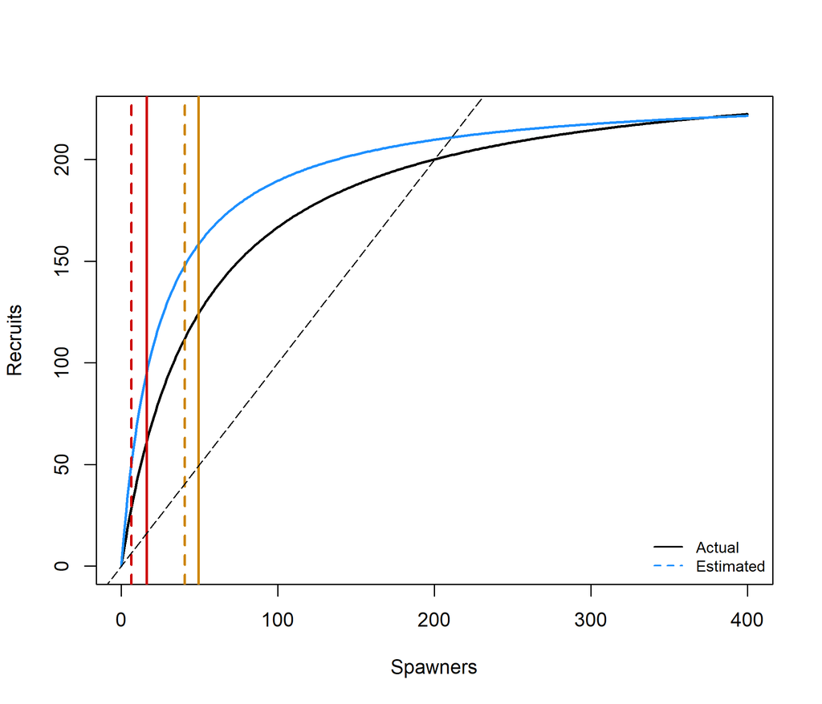

Adult and recruitment relationship with actual versus estimated (via maximum likelihood) SFF policy reference points.

```r
plot(0:(2*beta),population_model(alpha=alpha,beta=beta,0:(2*beta))$recruits,xlab="Spawners",ylab="Recruits",type="l",lwd=2)
lines(0:(2*beta),population_model(alpha=alpha_est,beta=beta_est,Nadults=0:(2*beta),model="Beverton-Holt")$recruits,type="l",lwd=2,col="dodgerblue")
abline(v=0.8*S_msy,lty=1,lwd=2,col="orange3")
abline(v=0.8*S_msy_est,lty=2,lwd=2,col="orange3")

abline(v=Sgen,lty=1,lwd=2,col="red3")
abline(v=Sgen_est,lty=2,lwd=2,col="red3")

abline(b=1,a=0,lty=5,col="black")
legend("bottomright",c("Actual","Estimated"),bty="n",lwd=1.5,lty=c(1,2),pch=c(NA,NA),col=c("black","dodgerblue"),cex=0.8)
```

Not bad! Now, we have our reference points estimated (with uncertainty, but we don’t calculate that here) from a 40 year time-series. And, we can assess this population in the future and determine status like: is it undergoing overfishing $U_{t}>U_{MSY}$ or it overfished $S_t<0.8S_{MSY}$. Or even, is it at a conservation concern $S_t<S_{GEN}$. Such is the power of the quantitative approach.

If interested, we could revisit all of the above estimation assuming Ricker instead of Beverton-Holt dynamics. Or, assuming correlated versus independent recruitment deviates. Feel free to play around.

## References

Forrest, R.E., McAllister, M.K., Dorn, M.W., Martell, S.J.D. & Stanley, R.D. (2010). [Hierarchical Bayesian estimation of recruitment parameters and reference points for Pacific rockfishes (Sebastes spp.) under alternative assumptions about the stock–recruit function](https://doi.org/10.1139/f10-077). *Canadian Journal of Fisheries and Aquatic Sciences*, 67, 1611–1634.

Frid, A., Wilson, K.L., Walkus, J., Forrest, R.E. & Reid, M. (2023). [Re-imagining the precautionary approach to make collaborative fisheries management inclusive of Indigenous Knowledge Systems](https://doi.org/10.1111/FAF.12778). *Fish and Fisheries*, 24, 940–958.

Methot, R.D. & Taylor, I.G. (2011). [Adjusting for bias due to variability of estimated recruitments in fishery assessment models](https://doi.org/10.1139/f2011-092). *Canadian Journal of Fisheries and Aquatic Sciences*, 68, 1744–1760.

Walters, C.J. & Martell, S.J.D. (2004). *Fisheries ecology and management*. Princeton University Press.